# Multipanel Figures

Haley Carter

2023-10-10

## Today’s packages

- readr - for reading in data, part of tidyverse
- ggplot2 - for plotting, part of tidyverse
- patchwork - a package for “composing” plots into figures
- ggpubr - a package for formatting ggplots as publication-ready figures

To learn more about any of these (or any other!) packages, you can search them in Help or click their names in Packages. We will definitely not cover everything they can do in one hour.

Please install the packages we will use today if you don’t already have them:

```r
# if you need to install any of the packages we're going to use today you can use the install.packages() function as written below by replacing packageName with the name of the package you'd like to install
install.packages("packageName")
```

And then load the packages into your library:

```r
# in addition to having the packages installed, we need to load them into our library so we can use their functions
library(readr)
library(ggplot2)
library(patchwork)
library(ggpubr)
```

## Data

```r
pumpkin_production <- read_csv("data/pumpkin_production.csv")
pumpkin_varieties <- read_csv("data/pumpkin_varieties.csv", skip = 1,
                              col_names = c("variety",
                                            "days_mature",
                                            "size_lbs",
                                            "powdery_hybrid",
                                            "resistance",
                                            "notes"),
                              col_types = cols(powdery_hybrid = col_factor(),
                                               resistance = col_factor()))
```

## Plots as objects

The following code chunk creates a ggplot object that loads in the plot window. Go ahead and run it.

```r
ggplot(pumpkin_production, aes(year, pumpkin_kcwt))+
  geom_col(fill = "orange")+
  labs(x = "Year", y = "Pumpkin production\n (units of 1000 hundredweights)")+
  theme_minimal()
```

To work with this graph, we want to save it as a named object so we assign it to a name:

```r
pump_prod <- ggplot(pumpkin_production, aes(year, pumpkin_kcwt))+
  geom_col(fill = "orange")+
  labs(x = "Year", y = "Pumpkin production\n (units of 1000 hundredweights)")+
  theme_minimal()
```

Note that that code chunk does not output a plot, but rather saves a new ggplot object to your environment. Like other objects, it has attributes you could use the $ notation to index. But you’re probably most interested in plotting it, which you can do by just running the name:

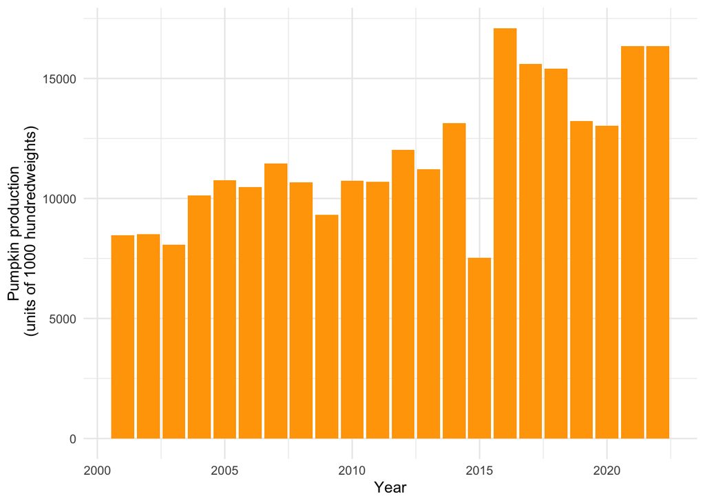

```r
pump_prod
```

### Exercise 1: Save some named plots

The following code creates some plots. Please save them with the following names:

```r
pump_time <- ggplot(pumpkin_varieties, aes(days_mature, variety))+
  geom_col()+
  theme_minimal()+
  labs(y = "Variety", x = "Days to maturity")

pump_size <- ggplot(pumpkin_varieties, aes(size_lbs, variety))+
  geom_col()+
  theme_minimal()+
  labs(y = "Variety", x = "Size at maturity (lbs)")

hybrid_grow <- ggplot(pumpkin_varieties[pumpkin_varieties$powdery_hybrid == "yes",], aes(days_mature, size_lbs))+
  geom_point()+
  theme_minimal()+
  labs(x = "Days to maturity", y = "Size at maturity (lbs)")

nonhybrid_grow <- ggplot(pumpkin_varieties[pumpkin_varieties$powdery_hybrid == "no",], aes(days_mature, size_lbs))+
  geom_point()+
  theme_minimal()+
  labs(x = "Days to maturity", y = "Size at maturity (lbs)")
```

## Putting the plots together - ggpubr

The ggpubr package contains a function called ggarrange() used to arrange plots. The plots are included as arguments separated by a comma. ggarrange() operates on a grid, you can use the ncol, and nrow arguments to set the size of the grid. It will fill from top to bottom and left to right.

### Example

```r
ggarrange(pump_prod, pump_grow)
```

### Exercise 2: Arrange plots side by side

Use ggarrange() to create a figure with pump_time next to pump_size.

### Adding labels

Most publications require labels on each panel of a multipanel plot. With ggarrange() you can add these with the labels argument.

```r
ggarrange(pump_time, pump_size, labels = c("A", "B"))
```

### Other helpful arguments

ggarrange() has many other arguments, allowing more customization. widths can be used to adjust the relative sizes of different plots. align can be used to align the axes. font.label takes a list that can be used to adjust the size, color, and font of the labels. You can access the documentation for ggarrange by typing ?ggarrange() in the console.

### Example

```r
ggarrange(pump_time, pump_size, labels = c("A", "B"), widths = c(1, 2))
```

### Exercise 3:

Use ggarrange() to layout the scatterplots (hybrid_grow and nonhybrid_grow) on the left and the barplots (pump_time and pump_size) on the right with lettered panel labels and the barplots twice as wide as the scatterplots.

But what if you’re not working on a grid?

## patchwork

The patchwork package is useful for more complicated layouts.

Run these line by line and see what they do!

```r
pump_time + pump_size
pump_time | pump_size
pump_time / pump_size
```

patchwork uses the arithmetic operators to work with ggplot objects to arrange them. Because R knows what kind of objects it’s working with, you can switch between using them for arithmetic and using them to arrange plots pretty seamlessly!

But the more complicated the layout, the more complicated the syntax. Try the following line:

```r
pump_time + pump_size / pump_prod
```

Order of operations is built into these operators so the forward slash or division sign is being evaluated first, followed by the plus sign, and because there is now a top and a bottom, it’s adding the pump_time graph to both.

You can get around this with () like you would with a mathematical expression, or you can save named pieces of your figure and then put them together.

```r
# with parentheses
(pump_time | pump_size) / pump_prod
# in steps
varieties <- pump_time + pump_size
varieties / pump_prod
# with ggarrange and patchwork together
varieties2 <- ggarrange(pump_time, pump_size)
varieties2 / pump_prod # layout is not quite as nice
```

### Exercise 4:

Use patchwork to create a figure with hybrid_grow next to nonhybrid_grow.

### Adding labels

To add labels with patchwork, you use the plot_layout() and plot_annotation() functions. Note: for some reason this doesn’t work if you use the | without putting that part of your expression in ().

```r
hybrid_grow + nonhybrid_grow + plot_annotation(tag_levels = "A")
```

plot_annotation() has many other arguments for adding other types of annotation such as titles or captions, and plot_layout() can also be added to figures to define a grid like ggarrange() does.

### Exercise 5:

Compose a figure with the two scatterplots next to each other, on top of the two barplots next to each other, all over the pump_prod barplot, with labels. This can be done just with patchwork or just with ggarrange or with a combination of the two. If you succeed one way and have extra time, try with the other package!

## Saving figures

You can use the RStudio GUI to save figures, or use the ggsave() function:

1. From the Plots panel you choose “Export” and pick an export filetype and specify the dimensions.
2. ggsave() saves ggplots (or other grid objects) with the desired filename for your figure as the first argument. It will default to save the current or most recent plot from the plot window, but has many helpful arguments for choosing which plot, or choosing the dimensions and format. Check them out with ?ggsave()

## More to learn!

### ggpubr

ggpubr has many other functions beyond ggarrange(), including functions for plotting that have a more similar syntax to base R. If you like the ggplot aesthetics and ability to use ggarrange() but haven’t learned all the ggplot syntax this is an alternative with potentially less learning curve. It also includes some nice built in themes. Learn more at the link below.

https://rpkgs.datanovia.com/ggpubr/

### patchwork

Next steps with patchwork would be to explore more of the functionality of plot_layout() and plot_annotation(). The resources below are a great place to start.

https://patchwork.data-imaginist.com/articles/guides/layout.html#controlling-guides

https://patchwork.data-imaginist.com/articles/guides/annotation.html